# 2.4. Bayes' Theorem

Suppose there are two jars of cookies. jar 1 contains 30 vanilla cookies and 10 chocolate cookies. jar 2 contains 20 of each. Now suppose you choose one of the jars at random and, without looking, select a cookie at random. The cookie is vanilla. What is the probability that it came from jar 1?

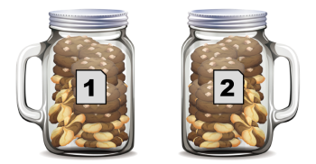

This is a conditional probability; we want $P(Jar1 | Vanilla)$, but it is not obvious how to compute it.

However, a different question — The probability of a Vanilla cookie given jar1 — it would be easy:

$$P( Vanilla |Jar 1) = 3/4$$

Sadly, $P(A|B)$ is not the same as $P(B|A)$ , but there is a way to get from one to the other: Bayes’s Theorem.

# 2.4. Bayes' Theorem

In this section we present two useful results of probability theory. The first one, the law of total probability, allows us at times to evaluate probabilities of events that are difficult to obtain alone, but become easy to calculate once we condition on the occurrence of a related event. First we assume that the related event occurs, and then we assume it does not occur. The resulting conditional probabilities help us compute the total probability of occurrence of the event of interest.

The second rule, the famous Bayes’ theorem, is easily derived from the law of total probability and the definition of conditional probability. The rule, discovered in 1761 by the English clergyman Thomas Bayes, has had a profound impact on the development of statistics and is responsible for the emergence of a new philosophy of science. Bayes himself is said to have been unsure of his extraordinary result, which was presented to the Royal Society by a friend in 1763—after Bayes’ death.

## The Law of Total Probability

Consider two events $A$ and $B$. Whatever may be the relation between the two events, we can always say that the probability of $A$ is equal to the probability of the intersection of $A$ and $B$, plus the probability of the intersection of $A$ and the complement of $B$ (event $B$) i.e.,

$$P(A) = P(A \cap B) + P(A \cap \bar B)$$

The sets $B$ and $\bar B$ form a partition of the sample space. A partition of a space is the division of the space into a set of events that are mutually exclusive (disjoint sets) and cover the whole space. Whatever event $B$ may be, either $B$ or $\bar B$ must occur, but not both.

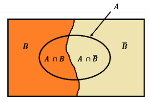

The law of total probability can be extended by using the definition of conditional probability.

Recall that $P (A \cap B) = P (A | B) P(B)$ and, similarly, $P (A \cap {\bar B}) = P (A | {\bar B}) P({\bar B})$.

Substituting these relationships into above equation gives us another form of the law of total probability.

The law of total probability using conditional probabilities (**Two-set case**):

$$ \boxed {P(A) = P(A | B)P(B) + P(A|\bar B)P(\bar B)}$$

The law of total probability may be extended to more complex situations, where the sample space $X$ is partitioned into more than two events. Say we partition the space into a collection of $n$ sets $B_1, B_2, . . . , B_n$. The law of total probability in this situation is

$$P(A) = \sum_{i=1}^{n}P(A \cap B_i)$$

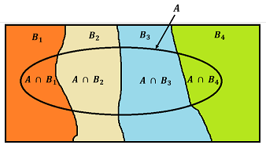

Above figure shows the partition of a sample space into the four events $B_1, B_2, B_3,$ and $B_4$ and shows their intersections with set $A$.

A practical example for this can be found in the deck of cards, where getting a face card (Jack,Queen,King) is a subset of union of 4 suits (Club, Spade, Hearts, Diamond).

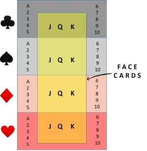

$P(Face \; Card) = P(Club \cap Face \; Card) + P(Spade \cap Face \; Card) + P(Hearts \cap Face \; Card) + P(Diamond \cap Face \; Card)$

In the below equation, we have a set of conditioning events $B_i$ that span the entire sample space, instead of just two events spanning it, $B$ and $\bar B$.

**More than two sets in the partition**:

$$P(A) = \sum_{i=1}^{n}P(A | B_i)P(B_i)$$

where there are $n$ sets in the partition: $B_i, i = 1, . . . , n$.

### Example:

A certain toy is manufactured by three different Machines, M1, M2, and M3. Half of the toys are produced by M1, and M2 and M3 each produce 25%. The probability of a toy being damaged given that it was produced by M1 is 1%, while it's 2% for M2 and 3% for M3. *What is the probability of a toy being damaged?*

**Solution:**

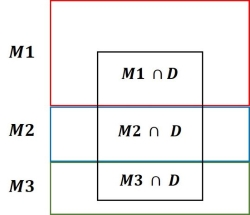

Using the *Law of Total Probability for more than two sets,*

```python
#Using Python

P_M1 = 0.5
P_M2 = 0.25
P_M3 = 0.25

P_D_g_M1 = 0.01
P_D_g_M2 = 0.02
P_D_g_M3 = 0.03

P_Damaged = (P_M1 * P_D_g_M1) + (P_M2 * P_D_g_M2) + (P_M3 * P_D_g_M3)

print('Probability of a toy being damaged = ',P_Damaged)
```

```
Probability of a toy being damaged =  0.0175
```

## Bayes' Theorem

We now develop the well-known Bayes’ theorem. The theorem allows us to reverse the conditionality of events: we can obtain the probability of $B$ given $A$ from the probability of $A$ given $B$ (and other information).

By the definition of conditional probability,

$$ P(B | A) = \frac {P(A \cap B)} {P(A)} $$

By another form of the same definition,

$$ P(A \cap B) = P(A | B)\;P(B) $$

Substituting second equation into the first equation gives:

$$ \boxed {P(B | A) = \frac {P(A | B)\;P(B)} {P(A)}} $$

We can use it to **solve the cookie problem using Bayes Theorem**.

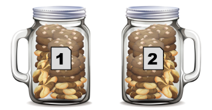

The term on the left is what we want: the probability of Jar 1, given that we chose a Vanilla cookie. The terms on the right are:

- $P(J_1)$: The probability that we chose Jar 1, unconditioned by what kind of cookie we got. Since the problem says we chose a Jar at random, we can assume $P(J_1) = 1/2$.
- $P(V|J_1)$: This is the probability of getting a vanilla cookie from Jar1, which is $3/4$.
- $P(V)$ : This is the probability of drawing a vanilla cookie from either Jar. we can compute $p(V)$ using the law of total probability

$$P(V) = P(V|J_1) P(J_1) + P(V|J_2) P(J_2) $$

[output not shown]

$$P(V) = (3/4) (1/2) + (1/2) (1/2) = 5/8 $$

Putting it together, we have

$$P(J_1|V) = \frac {(3/4)\;(1/2)} {(5/8)} $$

From the law of total probability using conditional probabilities we have,

$$ P(A) = P(A|B)\;P(B) + P(A | \bar B)\;P(\bar B) $$

Substituting this expression for $P(A)$ in the denominator of equation for $ P(B | A)$ gives us a **special case of the Bayes’ theorem is when event 𝐵 is a binary variable**. In such a case, the theorem is expressed in the following way:

**Bayes' Theorem:**

$$ \boxed {P(B|A) = \frac {P(A|B)\;P(B)} {P(A|B)\;P(B) + P(A | \bar B) \;P(\bar B)}} $$

As we see from the theorem, the probability of $B$ given $A$ is obtained from the probabilities of $B$ and $\bar B$ and from the conditional probabilities of $A$ given $B$ and $A$ given $\bar B$.

### Example

Imagine you have been diagnosed with a very rare disease, which only affects 0.1% of the population; that is, 1 in every 1000 persons.

The test you have taken to check for the disease correctly classifies 99% of the people who have the disease, incorrectly classifying healthy individuals with a 1% chance.

After this test, what are the chances that you are actually suffering from the disease?

**Solution:**

Let $𝑍$ denote the event that the test result is positive and $𝐼$ the event that the person tested is ill. So,

$P(I | Z)$ i.e., probability of having the disease given that you are being diagnosed positive of this disease in the test is to be calculated using the following formulation:

$$ P(I|Z) = \frac {P(Z|I)\;P(I)} {P(Z|I)\;P(I) + P(Z | \bar I)\; P(\bar I)} $$

The preceding information gives us the following probabilities of events:

$P(I) = 0.001$ i.e., the probability of having the disease before any test has been taken.

$P(\bar I) = 0.999$ i.e., probability of not having the disease.

$P(Z|I) = 0.99$ i.e., probability of being diagnosed positive in the test, given that we have the disease.

$P (Z|\bar I) = 0.01$ i.e., probability of being diagnosed positive in the test, given that we are healthy.

**NOTE :** $\bar I$ denotes the complementary of $I$ which is not having the disease.

Thus,

9%! There is only a 9% chance that you have the disease!

```python
#Using Python

# Individual probabilities & conditional probabilities
P_ill = 0.001
P_not_ill = 1 - P_ill
P_Positive_g_ill = 0.99
P_Positive_g_not_ill = 0.01

# Probability of Positive
P_Positive = (P_ill * P_Positive_g_ill) + (P_not_ill * P_Positive_g_not_ill)

# Bayes' rule for P(ill|Positive)
P_ill_g_Positive = (P_ill * P_Positive_g_ill) / P_Positive

print('Probability that the person is ill given the test is positive =',P_ill_g_Positive)
print('i.e.,', round(P_ill_g_Positive * 100,2), '%' )
```

```
Probability that the person is ill given the test is positive = 0.09016393442622951
i.e., 9.02 %
```

## Extended Bayes' Theorem

Bayes’ theorem may be extended to a partition of more than two sets. This is done using the law of total probability involving a partition of sets $B_1, B_2, . . . , B_n.$ The theorem gives the probability of one of the sets in partition $B_1$ given the occurrence of event $A$. A similar expression holds for any of the events $B_i$.

$$ \boxed {P(B_1|A) = \frac {P(A|B_1)\;P(B_1)} {\sum_{i=1}^{n}P(A|B_i)\;P(B_i)}} $$

### Example:

A certain toy is manufactured by three different Machines, M1, M2, and M3. Half of the toys are produced by M1, and M2 and M3 each produce 25%. The probability of a toy being damaged given that it was produced by M1 is 1%, while it's 2% for M2 and 3% for M3. A toy is checked at random and is found defective, *what is the probability that the defective toy was produced by M1* ?

**Solution:**

Using Extended Bayes Theorem,

```python
#Using Python

P_M1 = 0.5
P_M2 = 0.25
P_M3 = 0.25

P_D_g_M1 = 0.01
P_D_g_M2 = 0.02
P_D_g_M3 = 0.03

P_Damaged = (P_M1 * P_D_g_M1) + (P_M2 * P_D_g_M2) + (P_M3 * P_D_g_M3)


P_M1_g_D = (P_M1 * P_D_g_M1) / P_Damaged # P(M1|D) calculation

print('Probability that the defective toy was produced by M1 =',P_M1_g_D)
```

```
Probability that the defective toy was produced by M1 = 0.2857142857142857
```

### Example

An economist believes that during periods of high economic growth, the value of Indian National Rupee (INR) appreciates with probability 0.70; in periods of moderate economic growth, the INR appreciates with probability 0.40; and during periods of low economic growth, the INR appreciates with probability 0.20. During any period of time, the probability of high economic growth is 0.30, the probability of moderate growth is 0.50, and the probability of low economic growth is 0.20. Suppose the INR has been appreciating during the present period. What is the probability we are experiencing a period of high economic growth?

**Solution:**

$P(A | H) = 0.70$, $P(A | M) = 0.40$, and $P(A | L) = 0.20$. Applying Extended Bayes' Theorem while using three sets $(n = 3)$, we get

$$ P(H|A) = \frac {P(A|H)P(H)} {P(A|H)P(H)+P(A|M)P(M)+P(A|L)P(L)} $$$$ P(H|A) = \frac {(0.70)(0.30)} {(0.70)(0.30)+(0.40)(0.50)+(0.20)(0.20)} = 0.467$$

```python
# python implementation is left as a practice to students
```

Obtain $P(M|A) = ??$ and $P(L|A) = ??$

```python
# solution left as exercise for students
```

**Question :**

A company has two plants to manufacture scooters. Plant 1 manufactures 80% of the scooters and Plant 2 manufactures 20%. At Plant 1, 85 out of 100 scooters are rated standard quality. At Plant 2, only 65 out of 100 scooters are rated standard quality. What is the probability that the scooter came form Plant 2 if it is known that the scooter is of standard quality?

```python
# solution left as exercise for students
```